# DATA472_Assignment1

Vincent Yu 300390526

3/18/2021

### Q1. (3 Marks) Classify the following variables as categorical/numerical and further classify as logical, nominal, ordinal, binary, continuous or discrete. Give the R data type that corresponds to each.

#### Age of a person : Numerical, Continuous (as we can descibe the age of person with infinite number of decimal places) R data type: can use numeric or double

#### Gender of a person : Categorical, Nomial, R data type: character

#### Number of job applications made before employment: Numerical, Discrete, R data type: integer

#### Time between becoming unemployed and finding a new job: Numerical, Continuous, R data type can be numeric or double

#### Level of satisfaction with customer service (scale 1-10): Categorical, Ordinal, R data type can be character

#### Party voted for at the last election: Numerical, Continuous (if asking for like the percentage for each party get in the election) R data type can use double or numeric

### Q2. (4 Marks) [Note: for this question the file aaa.csv will not be available on the submission server. So you should set eval=FALSE in each R chunk, or the code will fail and your assignment won’t knit.]

```r
#Q2.a
bbb <- read.csv(file = "aaa.csv") # Read csv file to a dataframe named bbb
#Q2.b
n<-ncol(bbb) # extract the number of columns in the dataframe
#Q2.c
bbb<-bbb[-c(n)] #Delete the last column
#Q2.d Copy the second column and add it to the dataframe
temp <- bbb[,2]
bbb <- cbind(bbb,temp)
```

### Q4. (2 Marks) When measuring angles values less than 0 or greater than 360 can be converted into the range [0,360].Write R code that takes the vector x of angles c(-45, -345, 610, 23, 705) and converts them into the correct angles in the range [0,360].

```r
#Q4
x = c(-45, -345, 610, 23, 705)
res = c()
for (i in x) {
  while(TRUE){
    if(i<0 || i>360){
      if(i<0){
        i=i+360
      }
      else{
        i=i-360
      }
    }
    else{
      break
    }
  }
  res = c(res,i)
}
res
```

```
## [1] 315  15 250  23 345
```

### Q5. (7 Marks) In each of the questions below, show any R output your code produces, in order to verify your answers. Write R code to define the following objects

```r
# Q5.a
a <- array(c(22,13,-4,22),dim=c(4,1))
b <- array(c(2,3,6,0),dim=c(2,2))
c <- array(c(22,88),dim=c(2,1))
d <- array(c(22,13,0,6),dim = c(4,1))

#Q5.b
print("result  for Q5.b : ")
```

```
## [1] "result  for Q5.b : "
```

```r
b[1,2] #Top right element
```

```
## [1] 6
```

```r
#Q5.c
q5c<-array(c(c,c), dim = c(2,2))
print("result  for Q5.c : ")
```

```
## [1] "result  for Q5.c : "
```

```r
q5c
```

```
##      [,1] [,2]
## [1,]   22   22
## [2,]   88   88
```

```r
#Q5.d
allValues = c()
checkValue <- function(x) { ## A function that will look through the vectors and return the values that less than 13
  res=c()
  for (i in x) {
    if(i<13){
      res=c(res,i)
    }
  }
  return(res)
}
res<-checkValue(a)
print("result  for Q5.d : ")
```

```
## [1] "result  for Q5.d : "
```

```r
print("Here is the values in a that are less than 13")
```

```
## [1] "Here is the values in a that are less than 13"
```

```r
res
```

```
## [1] -4
```

```r
# Q5.e
val =c()
for(i in a){
  if(i<13){
    val =c(val,i)
  }
}
pos = match(val,a)
print("result  for Q5.e : ")
```

```
## [1] "result  for Q5.e : "
```

```r
print("Here is the position of elements in a that are less than 13")
```

```
## [1] "Here is the position of elements in a that are less than 13"
```

```r
pos
```

```
## [1] 3
```

```r
# Q5.f
val =c()
for(i in d){
  if(i<10){
    val =c(val,i)
  }
}
pos = match(val,d)
res=c()
pos
```

```
## [1] 3 4
```

```r
for (p in pos) {
  res =c(res,a[p])

}
print("result  for Q5.f : ")
```

```
## [1] "result  for Q5.f : "
```

```r
res
```

```
## [1] -4 22
```

### Q6. (15 Marks) Read the dataset sample500.csv from the course website: it contains a sample of 500 state houses in a dataset provided by Motu Public

```r
stateh <-read.csv(file="sample500.csv")
#Q6.a
dimension = dim(stateh)
print("The dimenson of the dataset is : ")
```

```
## [1] "The dimenson of the dataset is : "
```

```r
dimension
```

```
## [1] 500  40
```

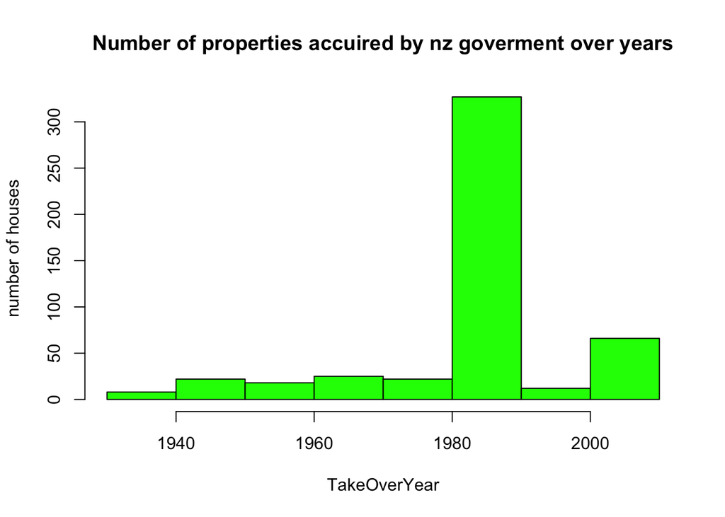

```r
#Q6.b
stateh <-read.csv(file="sample500.csv")
tky = stateh$takeover_year
hist(stateh$takeover_year, xlab = "TakeOverYear",ylab="number of houses", main = "Number of properties accuired by nz goverment over years", col= "green")
```

```r
stateh <-read.csv(file="sample500.csv")
#Q6.c
print("Here is how many properties sold to private owner")
```

```
## [1] "Here is how many properties sold to private owner"
```

```r
print(sum(!is.na(stateh$settled_year)))
```

```
## [1] 104
```

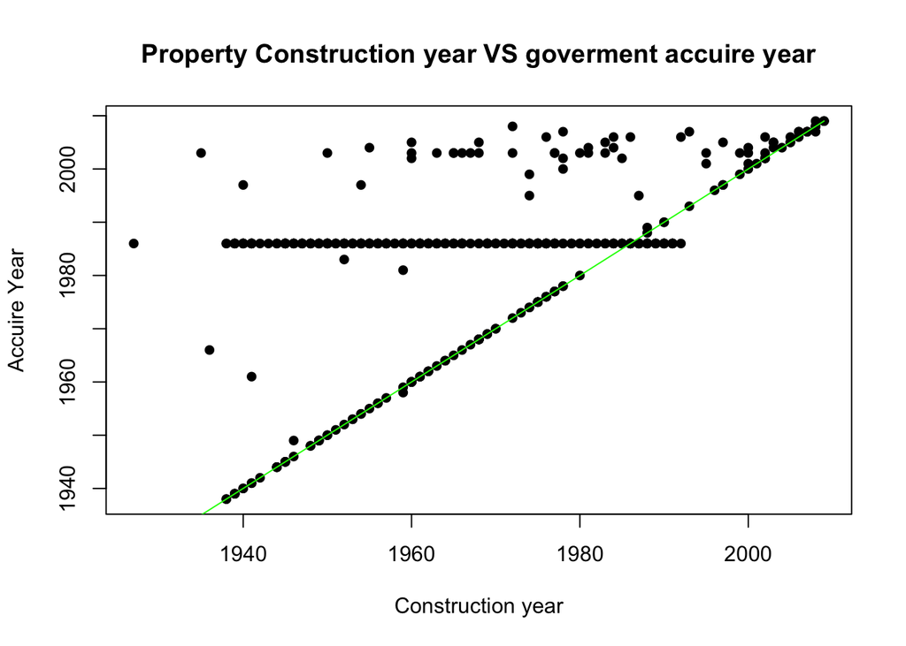

```r
#Q6.d
stateh <-read.csv(file="sample500.csv")
x =1920:2009
y =1920:2009
plot(stateh$prop_cnstr_date,stateh$takeover_year,main = "Property Construction year VS goverment accuire year", xlab="Construction year", ylab = "Accuire Year" ,pch=16)
lines(x,y,col="green")
```

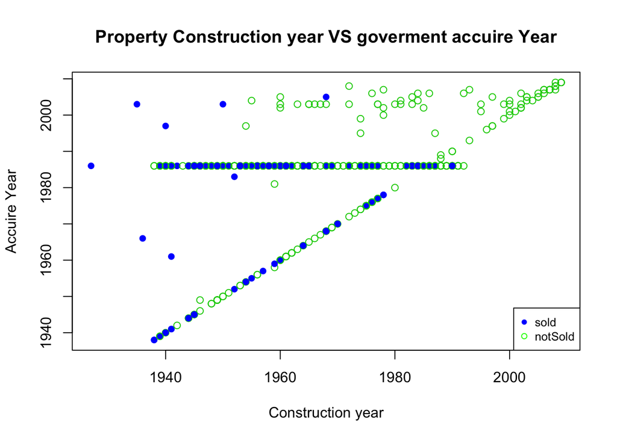

```r
#Q6.e
df <-read.csv(file="sample500.csv")
df$settled_year[!is.na(df$settled_year)] <-20
df$settled_year[is.na(df$settled_year)] <- 1

plot(df$prop_cnstr_date,df$takeover_year, main = "Property Construction year VS goverment accuire Year", xlab="Construction year", ylab = "Accuire Year", pch=pmin(df$settled_year,16), col=pmin(df$settled_year)*3)

legend(x="bottomright", legend=c("sold", "notSold"),
       col=c("blue", "green"),  cex=0.8, pch = c(16,1))
```

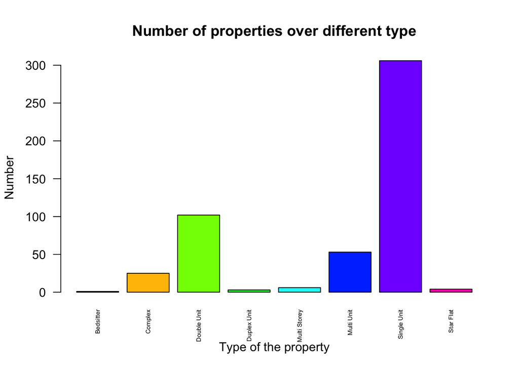

```r
# Q6.f
stateh <-read.csv(file="sample500.csv")
barplot(table(stateh$property_type), cex.names = 0.5, las=2, col = rainbow(8),main = "Number of properties over different type", xlab ="Type of the property", ylab="Number")
```

```r
#Q6.g
df <-read.csv(file="sample500.csv")
soldYears = df$settled_year
res = soldYears - df$prop_cnstr_date

df$age_at_sale = res
findMin<-df
findMin$age_at_sale[is.na(findMin$age_at_sale)] <- 1000
print("The minimum number of years for a house sold after consturction is" )
```

```
## [1] "The minimum number of years for a house sold after consturction is"
```

```r
min(findMin$age_at_sale)
```

```
## [1] 10
```

```r
print("The average number of years for a house sold after consturction is" )
```

```
## [1] "The average number of years for a house sold after consturction is"
```

```r
mean(res, trim=0, na.rm = TRUE)
```

```
## [1] 41.28846
```

```r
print("The median number of years for a house sold after consturction is" )
```

```
## [1] "The median number of years for a house sold after consturction is"
```

```r
median(res, trim=0, na.rm = TRUE)
```

```
## [1] 42.5
```

```r
print("The Lower Quartile of number of years for a house sold after consturction is" )
```

```
## [1] "The Lower Quartile of number of years for a house sold after consturction is"
```

```r
quantile(res, trim=0, na.rm = TRUE,0.25)
```

```
## 25%
##  31
```

```r
print("The Upper Quartile of number of years for a house sold after consturction is" )
```

```
## [1] "The Upper Quartile of number of years for a house sold after consturction is"
```

```r
quantile(res, trim=0, na.rm = TRUE,0.75)
```

```
##  75%
## 52.5
```

```r
print("The Maximum number of years for a house sold after consturction is" )
```

```
## [1] "The Maximum number of years for a house sold after consturction is"
```

```r
max(res, trim=0, na.rm = TRUE)
```

```
## [1] 68
```

```r
#quantile()
#stateh #just check if it inserted correctly
```

```r
#Q6.h
n=nrow(stateh)
table(stateh$property_type)
```

```
##
##    Bedsitter      Complex  Double Unit  Duplex Unit Multi Storey
##            1           25          102            3            6
##   Multi Unit  Single Unit    Star Flat
##           53          306            4
```

```r
tab.tpe = table(stateh$property_type)
print("now change the values into percentage in the table")
```

```
## [1] "now change the values into percentage in the table"
```

```r
perc.tpe = 100*tab.tpe/n
perc.tpe
```

```
##
##    Bedsitter      Complex  Double Unit  Duplex Unit Multi Storey
##          0.2          5.0         20.4          0.6          1.2
##   Multi Unit  Single Unit    Star Flat
##         10.6         61.2          0.8
```

```r
#Q6.i
stateh <-read.csv(file="sample500.csv")
min=3000
max=-1
for (i in stateh$prop_cnstr_date) {
  if(!is.na(i)){
    if(i<min){min=i}
    if(i>max){max=i}
  }
}
print("The type of the oldest house is : ")
```

```
## [1] "The type of the oldest house is : "
```

```r
stateh[which(stateh$prop_cnstr_date ==min),]$property_type
```

```
## [1] Single Unit
## 8 Levels: Bedsitter Complex Double Unit Duplex Unit ... Star Flat
```

```r
print("The type of the youngest house is : ")
```

```
## [1] "The type of the youngest house is : "
```

```r
stateh[which(stateh$prop_cnstr_date ==max),]$property_type
```

```
## [1] Single Unit Multi Unit  Duplex Unit
## 8 Levels: Bedsitter Complex Double Unit Duplex Unit ... Star Flat
```

### Q7. (7 Marks) In statistics we often want to convert observations y1,…,yn into their standardised equivalents

```r
#Q7.a
standardise <- function(y,na.rm=FALSE){
  z <- (y-mean(y))/sd(y)
  return (z)
}

data = c(2,6,4,3,7,7,16,5,3,1)
res = standardise(data)
mean(res)
```

```
## [1] -9.989839e-17
```

```r
sd(res)
```

```
## [1] 1
```

```r
data=c(1,5,3)
```

#### From the result, we can see the mean value of the standardised vector is very close to zero. And the standard deviation of the output is 1 which confirms the function is corret.

```r
#Q7.b
standardise2 <-function(y){
  cleaning =c()
  for (i in y) {
    if (is.na(i)){
  }
  else{
    cleaning =c(cleaning, i)
  }
  }
    return (standardise(cleaning))
}
## Remove the NA value by the modified function
data=c(1,5,3,NA)
res = standardise2(data)
res
```

```
## [1] -1  1  0
```

```r
## Without Remove and using the function from previous question
data=c(1,5,3,NA)
resWithoutRemove = standardise(data)
print("Without Remove the missing data using the function in question a")
```

```
## [1] "Without Remove the missing data using the function in question a"
```

```r
resWithoutRemove
```

```
## [1] NA NA NA NA
```

```r
#Q7.c
standardise3 <-function(y){
  if (length(y)<=1){
    return (NA)
  }
  else{
    return (standardise2(y))
  }
}
data=c(1)
res = standardise3(data)
res
```

```
## [1] NA
```

```r
data=c(NA)
res = standardise3(data)
res
```

```
## [1] NA
```

```r
#Q7.d

standardise4 <-function(y){
  cleaner =c()
  for (i in y) {
    if (is.na(i)){
  }
  else{
    cleaner =c(cleaner, i)
  }
  }
  res = standardise3(cleaner) # using the previous function and check the value it return
  if(any(is.na(res))){
       message( "After remove NA, only one element left in the vector ")
    opt <- options(show.error.messages=FALSE)
    on.exit(options(opt))
    stop()
  }
  else{
    return (res)
  }
}


data =c(1,NA,3)
res = standardise4(data)
res
```

```
## [1] -0.7071068  0.7071068
```

```r
data1 =c(1,NA)
res1 = standardise4(data1)
```

```
## After remove NA, only one element left in the vector
```

```
## Error in standardise4(data1):
```